# Identificacion de los organismos cruciales frente a la neumonia

Matias Mogetta, Santiago Fontana y Emerio Tenreyro

# Introducción

La neumonía es una infección que inflama los sacos aéreos de uno o ambos pulmones. Los sacos aéreos se pueden llenar de líquido o pus (material purulento), lo que provoca tos con flema o pus, fiebre, escalofríos y dificultad para respirar. Ésta puede variar en gravedad desde suave a potencialmente mortal. Es más grave en bebés y niños pequeños, personas mayores a 65 años, y personas con problemas de salud o sistemas inmunitarios debilitados.

[figure not shown]

**Diferencia en sacos aereos con neumonia y sanos**

Los síntomas de las neumonías son variables, sin que ello tenga siempre relación con el tipo de germen causante de la neumonía. Algunos casos se presentan con lo que se llama una “neumonía típica”, que consiste en la aparición en varias horas o 2-3 días de tos con expectoración purulenta o herrumbrosa, en ocasiones con sangre, dolor torácico y fiebre con escalofríos.  
Si la neumonía es extensa o hay una enfermedad pulmonar o cardiaca previa puede aparecer dificultad respiratoria. Además, si los gérmenes pasan a la circulación sanguínea producen una bacteriemia que puede conducir a un “shock séptico”.  
En personas ancianas la presentación puede tener síntomas iniciales menos llamativos con fiebre poco elevada o ausente, tos escasa y con alteración del comportamiento.  
Las infecciones bacterianas, virales y fúngicas pueden causar neumonía, es decir que esta enfermedad puede ser contraída a partir de variados vectores.  
Las bacterias son la causa más común. La neumonía bacteriana puede ocurrir por sí sola. También puede desarrollarse después de haber tenido ciertas infecciones virales, como resfríos o gripe. Varios tipos diferentes de bacterias pueden causar neumonía, incluyendo a *Streptococcus pneumoniae*.  
Los virus que infectan las vías respiratorias pueden causar neumonía. A menudo, la neumonía viral es leve y desaparece por sí sola en pocas semanas. Pero en ocasiones es lo suficientemente grave como para necesitar tratamiento en un hospital. Si tiene neumonía viral, corre el riesgo de contraer también neumonía bacteriana. Los diferentes virus que pueden causar neumonía incluyendo al SARS-CoV-2, el virus que causa COVID-19.  
La neumonía fúngica es más común en personas con problemas de salud crónicos o sistemas inmunitarios debilitados.  
Si existe una sospecha de neumonía, el médico puede recomendarte los siguientes exámenes:

1. Análisis de sangre.
2. Radiografía torácica.
3. Pulsioximetría.
4. Prueba de esputo.

## Preguntas de investigacion

- ¿Hay una relación entre el género del paciente y la neumonía?
- ¿Hay una relación entre el diagnóstico de neumonía y alguna bacteria, hongo o virus?
- De los pacientes diagnosticados con neumonía con X bacteria, hongo o virus hallado, ¿Cuál es su porcentaje de mortalidad?¿Cuál es su frecuencia?¿Cómo podemos relacionar estas dos variables para encontrar el vector de mayor importancia?

Esperamos poder encontrar alguna relación entre la enfermedad de neumonía y características de género de una persona.  
Esperamos poder predecir correctamente cuáles son los organismos que causan neumonía.  
Esperamos, además, poder determinar qué tipo de neumonía es más mortal y cual se debería priorizar el desarrollo de un nuevo tratamiento.

## Distribucion en base al genero

Un grafico que muestra el porcentaje de pacientes en lo que respecta a su genero.

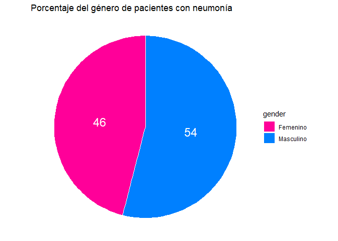

## Frecuencia y mortalidad de la enfermedad

Una gran manera de determinar la gravedad de una enfermedad es mediante no solo su indice de mortalidad, sino que tambien por su frecuencia, ya que ambos aportan una importante e interesante informacion.

### Frecuencia

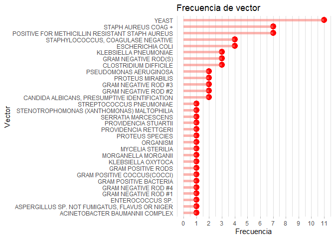

### Mortalidad

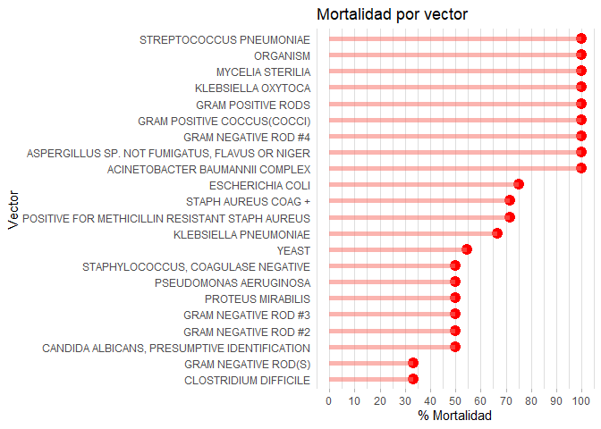

## Muertes totales por organismo

En este caso, el numero de muertes totales es un gran indicador por si solo del peligro que presenta la enfermedad, ya que enfermedades muy mortales pero poco frecuentes podrian tener un numero total de muertes menor al de una muy frecuente pero con un bajo indice de mortalidad.

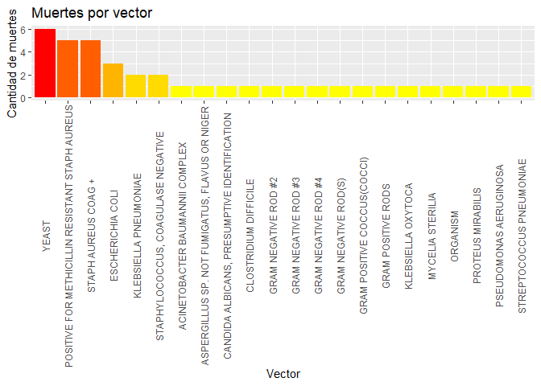

# Conclusión

### Resultados obtenidos

Los valores obtenidos se alinean logicamente con lo que esperabamos encontrar.

- La proporción de género en pacientes con neumonía es cercana a un 50% para cada género.
- Entre los vectores hallados que causan neumonía, se encuentra el Streptococcus pneumoniae, uno de los vectores de la enfermedad mencionados en la introducción.
- Entre los vectores hallados, hay variedades de bacterias y hongos como Streptococcus pneumoniae, Saccharomyces cerevisiae, Mycelia sterilia, pero no hallamos presencia notoria de virus.
- En cuanto a la mortalidad de cada organismo, no poseíamos información previa a la realización de la investigación, por lo que no podemos estimar la lógica de los resultados obtenidos.

### Respuestas a las preguntas de investigación

Con los resultados obtenidos podemos llegar a una conclusión para las 3 preguntas planteadas.

1. ¿Hay una relación entre el género del paciente y la neumonía?

Con los datos obtenidos, podemos afirmar que no hay una estricta relación entre el género del paciente y la neumonía. Pareciera que es una enfermedad que no tiene predilección por individuos masculinos o femeninos, sino que ambos son afectados por igual.

3. De los pacientes diagnosticados con neumonía con X bacteria, hongo o virus hallado, ¿Cuál es su porcentaje de mortalidad? ¿Cuál es su frecuencia? ¿Cómo podemos relacionar los datos obtenidos para encontrar los 3 vectores de mayor relevancia?

Tanto los porcentajes de mortalidad como la frecuencia con la cual fue encontrado cada vector en la población muestreada se pueden visualizar en en las figuras 2 y 3. No nos detendremos a analizar detalladamente aquí.  
La forma en la que usamos los datos para poder identificar los 3 vectores de mayor importancia fue decidida de manera arbitraria, según las mayores cantidades de muertes ocasionadas por cada vector. Teniendo en cuenta este criterio, los 3 vectores de mayor importancia son los siguientes, en orden jerárquico:

1. *Saccharomyces cerevisiae*
2. *Staphylococcus aureus* resistente a meticilina (antibiótico)
3. *Staphylococcus aureus* coagulasa positiva

### Discusión y posibles mejoras

Sin lugar a dudas podemos seguir indagando con la base de datos utilizada, para plantear más preguntas y relacionarlas con los datos obtenidos. Dentro de esta categoría entra una pregunta que fue planteada previamente pero no hemos podido responder:

- De los pacientes diagnosticados con neumonía con X bacteria, hongo o virus hallado, y recetados con X droga, ¿Cuál es la efectividad de cada droga?

Además, podríamos investigar más en profundidad acerca de la priorización del tratamiento de enfermedades, para poder alcanzar un criterio unificado sobre el cual determinar cuáles son los organismos más relevantes en la muestra.  
Por último, la utilización de una fuente de datos más grande le daría mayor relevancia estadística a los datos obtenidos, enriqueciendo nuestros resultados y conclusiones.

##### Bibliografía

[Mayo Foundation for Medical Education and Research. (29 de julio de 2021). Neumonía. Mayo Clinic. Recuperado el 6 de mayo de 2023.](https://www.mayoclinic.org/es-es/diseases-conditions/pneumonia/diagnosis-treatment/drc-20354210)  
[Clínica Universidad de Navarra. (s.f.). Neumonía: Síntomas, Diagnóstico y tratamiento. Clínica Universidad de Navarra. Recuperado el 6 de mayo de 2023.](https://www.cun.es/enfermedades-tratamientos/enfermedades/neumonia)  
[U.S. National Library of Medicine. (s.f.). Neumonía: Medlineplus en español. MedlinePlus. Recuperado el 6 de mayo de 2023.](https://medlineplus.gov/spanish/pneumonia.html)

###### Docentes:

Ignacio Casol, Nicolas gamboa.

###### Asistente:

Solange Blacutt.